# Will use my 2 late days for this problem set

### 2.3.3 - Try again with a few different ks and increase sample size. What are the outputs obtained from using different ks? What do the clusters contain? Explain

[figure not shown]

```python
k = 4
images2 = np.random.choice(images, 200) # smaller sample for speed

im1 = imread(os.path.join(imagedir, images2[0]))
imshape = im1.shape

X = np.empty(shape=(len(images2),imshape[0]*imshape[1]*imshape[2]))

for i, img in enumerate(images2):
    pixels = imread(os.path.join(imagedir, img))
    X[i,:] = pixels.ravel()
#####
clusteredKMeansTwo = KMeans(n_clusters = k, random_state = 42)

clusteredKMeansTwo.fit(X)
clusterLabels = clusteredKMeansTwo.predict(X)
clusterLabels = clusteredKMeansTwo.labels_
####


####



######
def plotcluster(X,imshape, clusterLabels, c):
    plt.suptitle('cluster' + str(c))
    plt.figure(figsize = (50,50))
    Xcl = X[clusterLabels == c]



    inds = np.random.choice(len(Xcl), 6, replace = False)
    for i, ind in enumerate(inds):
        ax = plt.subplot(2,3, i+1)
        array = Xcl[ind,:].reshape(imshape)
        ax.imshow(array.astype("uint8"))
        ax.axis("off")

    plt.show()

######
clusterView = 2 #has to be lesser than the clusters outputted
plotcluster(X,imshape, clusterLabels, clusterView)
```

[figure not shown]

```python
k = 5
images3 = np.random.choice(images, 300) # smaller sample for speed

im1 = imread(os.path.join(imagedir, images3[0]))
imshape = im1.shape


X = np.empty(shape=(len(images3),imshape[0]*imshape[1]*imshape[2]))

for i, img in enumerate(images3):
    pixels = imread(os.path.join(imagedir, img))
    X[i,:] = pixels.ravel()
#####
clusteredKMeansThree = KMeans(n_clusters = k, random_state = 42)

clusteredKMeansThree.fit(X)
clusterLabels = clusteredKMeansThree.predict(X)
clusterLabels = clusteredKMeansThree.labels_

####
def plotcluster(X,imshape, clusterLabels, c):
    plt.suptitle('cluster' + str(c))
    plt.figure(figsize = (50,50))
    Xcl = X[clusterLabels == c]


    inds = np.random.choice(len(Xcl), 6, replace = False)
    for i, ind in enumerate(inds):
        ax = plt.subplot(2,3, i+1)
        array = Xcl[ind,:].reshape(imshape)
        ax.imshow(array.astype("uint8"))
        ax.axis("off")

    plt.show()

######
clusterView = 2 #has to be lesser than the clusters outputted
plotcluster(X,imshape, clusterLabels, clusterView)
```

# 3. Images: Reduce the number of colors

## 3.1 Get a color image that you choose, load it as a matrix, and display it using matplotlib. You may use the code along these lines

```python
import matplotlib.pyplot as plt
from matplotlib.image import imread
```

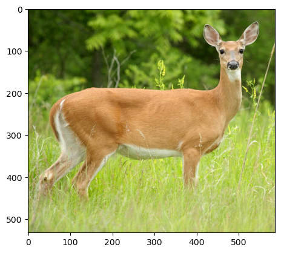

```python
pixels = imread("/Users/carloscura/Downloads/deer.img.jpeg")
ax = plt.axes()
ax.set_aspect("equal")
_ = plt.imshow(pixels)
_ = plt.show()
```

```python
print(pixels.shape)
```

```
(532, 587, 3)
```

```python
pixels.shape
M = pixels.reshape((-1, pixels.shape[2]))
print(M.shape)

print(pixels.shape)
```

```
(312284, 3)
(532, 587, 3)
```

```python
from sklearn.cluster import KMeans
```

```python
m = KMeans(16).fit(M)
c1 = m.predict(M)
centers = m.cluster_centers_
print("center color values:\n", centers)
```

```
center color values:
 [[ 80.19046286 107.21010521  24.29927591]
 [177.96989457 193.86029008  99.25891279]
 [ 37.58195955  55.93317258   7.40175188]
 [162.17614087 188.04829578  63.09738421]
 [207.02279239 155.70026917  96.93583398]
 [215.70385965 213.63338346 170.31368421]
 [156.9348997  108.57095097  49.82800892]
 [195.09464169 208.70077357 119.09937378]
 [184.85635053 176.18461295 135.72870612]
 [183.97612099 136.88925444  76.97118599]
 [153.18427554 154.36019474  92.29603255]
 [132.12391219 159.75807086  46.86570097]
 [232.5823991  178.47309417 124.48299701]
 [ 57.72548592  79.89925522  16.68788374]
 [104.4081116  134.79248467  31.73533217]
 [185.72247319 209.86251565  80.81706852]]
```

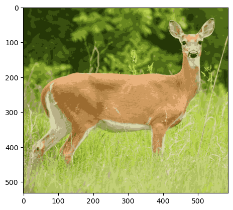

```python
compressed = centers[c1] / 255
compressed = compressed.reshape(pixels.shape)
ax = plt.axes()
ax.set_aspect("equal")
_ = plt.imshow(compressed)
_ = plt.show()
```

## 3.2 Get this code to work with your image and understand what it does. Explain:

(a) (0.4 point) What does the shape of pixels mean?

- Answer: The dimensionality.

  ```
    -Pixels in the code
    -Its a tuple that uses height, width, and channels (Number of color channels used) in that order
  ```

(b) (0.4 point) What is matrix M? Why does it have 671,040 rows and 3 columns in this example?

(c) (0.4 point) What do cl values tell us? E.g. if cl[12345] = 2, what does it mean?

- Answer: Its the application of Kmeans assigning clusters to every pixel individually
- cl[12345] = 2 represents the cluster assignment label when Kmeans was applied

(d) (0.4 point) What are the columns of “center color values” printed above? E.g. the first row, second column is value 163.37. What does that number mean?

- Answer: The columns of the center color values represent the average color schemes of R,G,B for each cluster which helps reconfigure my images color-code into reduced color schemes from the averages of colors used
- The value 163.37 comes from the average color of green within the 1st cluster(row)

(e) (0.4 point) How many “center color values” are there? Why do we have this number?

- Answer: The amount of center color values is represented by the amount I designated in my Kmeans model which is ---> 16
- We have this number for color optimization purposes to illuminate for processing using the color average on each pexil for each respective cluster
- Since we reduced our image to smaller 16 colors are the images we reduced to

## 3.3 Next repeat the above by reducing the number of colors to 2, and 4. Show the pictures!

```python
def imageRevise(imageLocation, colorCount):
    pixels = imread(imageLocation)
    M = pixels.reshape((-1, pixels.shape[2]))
    m = KMeans(n_clusters = colorCount).fit(M)
    c1 = m.predict(M)
    centers = m.cluster_centers_
    compressed = centers[c1] / 255
    compressed = compressed.reshape(pixels.shape)
    ax = plt.axes()
    ax.set_aspect("equal")
    _ = plt.imshow(compressed)
    _ = plt.show()
```

### Number of Colors = 2 colors

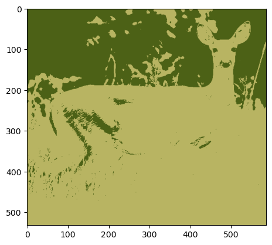

```python
imageRevise("/Users/carloscura/Downloads/deer.img.jpeg", colorCount = 2)
```

### Number of Colors = 4 colors

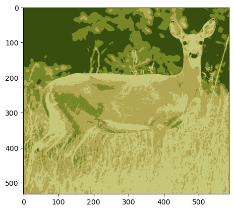

```python
imageRevise("/Users/carloscura/Downloads/deer.img.jpeg", colorCount = 4)
```

# I spent 12 - 14 hours on this problem set